# Bad Models

Bryce Bartlett

May 31, 2018

## Generating a Model Based on GSS

I build the model based on a subset of the GSS (this was previously cleaned for another project—should update with full GSS).

The generating formula is as follows:

```r
dat <- read.csv("H:/projects/gender_egal/output/private~/subdat.csv")

dat = dat %>%
  dplyr::rename(a=age,
         p=year) %>%
  dplyr::mutate(c = p-a,
         y=sin(p)+(c-1950)*.01+rnorm(nrow(dat))) %>%
  dplyr::select(a,p,c,y)
```

## The Stochastic Window Sampler Model

I estimate effects using the stochastic window sampler model as follows, and output the summary results of the sample and estimated effects.

```r
samp = apcsamp(dat = dat,
        cores=3,
        method='ml',
        samples=100)
```

```
## Deleting 185 incomplete cases
##
## Begin drawing 300 total samples from 3 parallel chains.
##       This will take some time. Calculating Estimate ...
```

[output not shown]

[output not shown]

[output not shown]

[output not shown]

```
##
## One sample took 5.2 seconds
## 300 parallelized would take at least 8.7 minutes.
##
## [1] "2018-06-02 13:53:03 EDT"
##
##
## End drawing chains...
```

```r
print(summary(samp))
```

```
##
##
## Samples: 300     over 3 chains.
## Acceptance: 0.48     Boundary Faults: 0
##
## Best-fitting from full APC
## BIC:  150199
## AIC:  149003.5
## R-squared:    0.3531685
##
##
## Mean Number Window Breaks:
##  a  p  c
## 47 19 71
##
##
## Convergence Diagnostics for sampling step:
##
##  Gewecke Diagnostic (p-value of convergence):     1.013
##  R-Hat (a value of 1 indicates convergence):  NA
##
## Test for null effects (assuming sufficient convergence):
## Using AIC, the Posterior Probability of the following null models being "correct" i.e. minimizing AIC):
##  No A effects:    0.000
##  No P effects:    0.000
##  No C effects:    1.000NULL
```

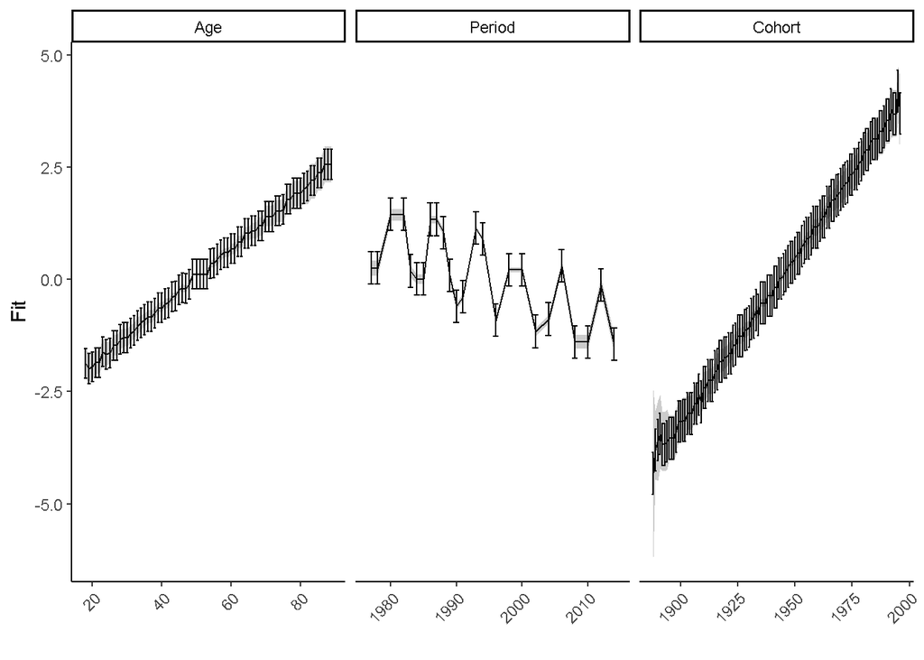

```r
effs = draw_effs(samp,tol=0.01)

plot(effs)
```

This appears erroneous because the summary suggests that the best fitting model is one where the cohort dimension is deleted, and the three-dimensional model shows an effect for age. (There also appears to be a negative trend in the sine wave of the period effect).

## Exploring the True Model and Alternative Specifications.

The code block below identifies three models: the true model, and the limit-case models with a deleted dimension using the block-modelling strategy, which treats each dimension as a unique factor variable. These block models are the equivalencies that we test in the SWS.

```r
true.m = lm(y~I(sin(p))+I(c-1950),data=dat)
noc.m = lm(y~factor(a)+factor(p),data=dat)
noa.m = lm(y~factor(p)+factor(c),data=dat)

kable(
  data.frame(True=AIC(true.m),
             c.excluded=AIC(noc.m),
             a.excluded=AIC(noa.m)),
  digits=2,
  caption='AIC from various models specifications.'
)
```

AIC from various models specifications.

| True | c.excluded | a.excluded |
| --- | --- | --- |
| 147167.1 | 147224.7 | 147307.7 |

The lowest AIC is the true model, followed by the model deleting the cohort dimension, and finally, the model deleting age. Why is this the case? It is because we are expanding the “true” two-dimensional model across three dimensions. In this case, the models with a deleted dimension are simply transformations of very similar models (like a statistical Necker Cube). This shows that the transformation of cohort into age is better able to minimize variance (as measured by AIC).

To make explicit that these are simply transformations of a three dimensional model, consider the following substitute transformations of the true model:

Substitute 1:

$$y = \beta_0 + \beta_1[sin(c)cos(a) + cos(c)*sin(a)] + \beta_2(c-1950) + \epsilon$$

Substitute 2:

$$y = \beta_0 + \beta_1[sin(p)] + \beta_2(p-a-1950) + \epsilon$$

If we distribute the estimate of $\beta_2$, we can get another substitute model:

Substitute 3:

$$\begin{align}
y &= \beta_0 + \beta_1[sin(p)] + beta_2p - \beta_2a - \beta_2(1950) + \epsilon \\
&= \beta_0^{\prime} + \beta_1[sin(p)] + \beta_2p + -\beta_2a + \epsilon
\end{align}$$

(Where $\beta_0^{\prime}$ is adjusted by a constant (negative) value from $\beta_0$).

We can run each of the models as follows:

```r
sub1.m = lm(y~I(sin(c)*cos(a)+cos(c)*sin(a))+I(c-1950),data=dat)
sub2.m = lm(y~I(sin(p))+I(p-a-1950),data=dat)
sub3.m = lm(y~I(sin(p))+p+a,data=dat)

kable(
  data.frame(True=AIC(true.m),
             Substitute.1=AIC(sub1.m),
             Substitute.2=AIC(sub2.m),
             substitute.3=AIC(sub3.m)),
  digits=2,
  caption='AIC from various models specifications.'
)
```

AIC from various models specifications.

| True | Substitute.1 | Substitute.2 | substitute.3 |
| --- | --- | --- | --- |
| 147167.1 | 147167.1 | 147167.1 | 147169 |

[Reference to trigonometric equivalencies.](https://brownmath.com/twt/sumdiff.htm#sincosAplusmnB)

Substitute 1 and 2 are exactly equivalent. Substitute 3 is slightly different; in any case, the predicted estimates are accurate.

```r
kable(
  data.frame(
    True = c(coef(true.m),NA),
    Substitute.1 = c(coef(sub1.m),NA),
    Substitute.2 = c(coef(sub2.m),NA),
    Substitute.3 = coef(sub3.m),
    row.names=c('Beta0','Beta1','Beta2','Beta3 (equals -1*Beta2)')
  ),
  digits=3,
  caption='Estimated Coefficients from Substitute Models.'
)
```

Estimated Coefficients from Substitute Models.

|  | True | Substitute.1 | Substitute.2 | Substitute.3 |
| --- | --- | --- | --- | --- |
| Beta0 | -0.005 | -0.005 | -0.005 | -19.440 |
| Beta1 | 0.996 | 0.996 | 0.996 | 0.996 |
| Beta2 | 0.010 | 0.010 | 0.010 | 0.010 |
| Beta3 (equals -1*Beta2) | NA | NA | NA | -0.010 |

Substitute 3 is nearly identical to the true model (in terms of AIC, it is indistinguishable), but it is completely specified *without* a cohort dimension. In addition, the age coefficient is statistically significant (because in Substitute 3 it acts as a partial transformation of the cohort effect along with the period coefficient).

```r
library(stargazer)
stargazer(list(true.m,sub3.m),type='text')
```

```
##
## ===============================================================================
##                                         Dependent variable:
##                     -----------------------------------------------------------
##                                                  y
##                                  (1)                           (2)
## -------------------------------------------------------------------------------
## I(sin(p))                     0.996***                      0.996***
##                                (0.006)                       (0.006)
##
## I(c - 1950)                   0.010***
##                               (0.0002)
##
## p                                                           0.010***
##                                                             (0.0004)
##
## a                                                           -0.010***
##                                                             (0.0003)
##
## Constant                       -0.005                      -19.440***
##                                (0.004)                       (0.841)
##
## -------------------------------------------------------------------------------
## Observations                   51,824                        51,824
## R2                              0.372                         0.372
## Adjusted R2                     0.372                         0.372
## Residual Std. Error      1.001 (df = 51821)            1.001 (df = 51820)
## F Statistic         15,380.830*** (df = 2; 51821) 10,253.710*** (df = 3; 51820)
## ===============================================================================
## Note:                                               *p<0.1; **p<0.05; ***p<0.01
```

Theoretically, this should be a problem in all cases where social time has only two dimensions. Specifically, because our tools use three dimensions to measure time. Because of this, all two-dimensional models have infinitely-many nearly-equivalent substitutes, it is impossible to say which is the *true* model, because if social time is truly two-dimensional, then age, period, and cohort, do not exist as such, and we need to develop a two-dimensional concept to describe social time.

Otherwise (as noted above) it is like a Necker cube, where there are multiple equivalent interpretations in three dimensions of the same two-dimensional object. The window sampler does not test all possible transformations of a, p, and c, but does test for the best transformation *within* the set of identified block models.

Why does the SWS choose the “incorrect” dimension to delete. I’m not completely certain, but I think it has to do with the covariance of age, period, and cohort. In particular, for the GSS, age and cohort are very highly (and negatively) correlated (-0.85). Age is much less correlated with period than cohort, however. This means that substituting age for cohort may give better leverage, and in fact, as shown above, for the window sampler, does minimize AIC (meaning it gets better prediction).

```r
vars = dat %>%
  dplyr::mutate(sinp = sin(p),
         clim = c-1950) %>%
  dplyr::select(sinp,clim,y,a,c,p)

kable(
  cor(vars,use='complete.obs'),
  digits=2,
  caption="Pearson correlations of variables and select transformations."
)
```

Pearson correlations of variables and select transformations.

|  | sinp | clim | y | a | c | p |
| --- | --- | --- | --- | --- | --- | --- |
| sinp | 1.00 | 0.07 | 0.59 | 0.02 | 0.07 | 0.16 |
| clim | 0.07 | 1.00 | 0.20 | -0.85 | 1.00 | 0.48 |
| y | 0.59 | 0.20 | 1.00 | -0.12 | 0.20 | 0.17 |
| a | 0.02 | -0.85 | -0.12 | 1.00 | -0.85 | 0.06 |
| c | 0.07 | 1.00 | 0.20 | -0.85 | 1.00 | 0.48 |
| p | 0.16 | 0.48 | 0.17 | 0.06 | 0.48 | 1.00 |

Notably, the SWS correctly identified that time is more likely two-dimensional. The block model that minimizes AIC when all three dimensions are included is the most efficient model, using variable transformations under particular requirements.

Because of this, I might delete the segment in the summary identifying which dimension to delete, and include instead a reference to a two-dimensional model. As it is, the returned model doesn’t sample from the deleted dimension model, either.